# Enska Úrvalsdeildin 2019/20

Til að halda áfram með rannsókn okkar á því hvaða lið stóð sig best, skoðum við nú sóknarleik liðanna með því að lesa út úr töflunni, Liðin.

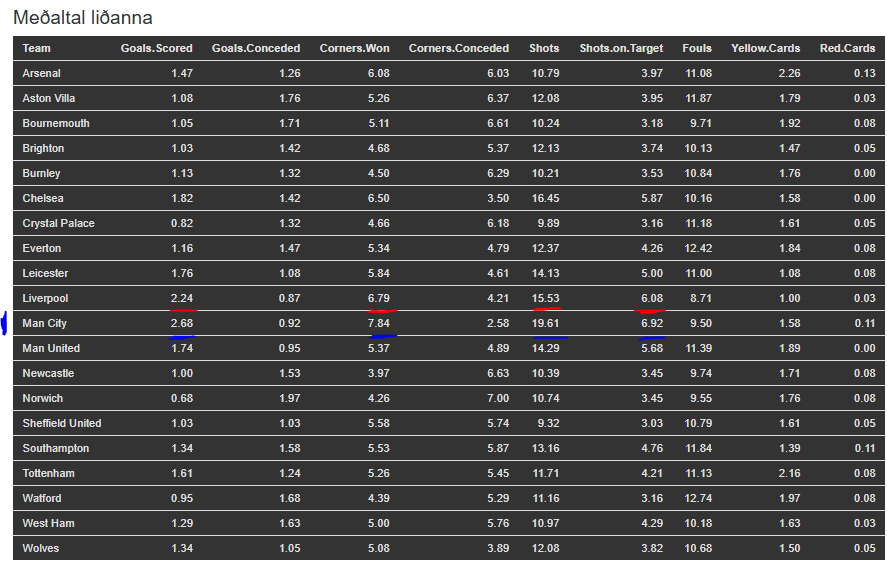

Liverpool og Manchester City tróna á toppnum í nánast öllum sóknarþáttum, svo sem mörkum skoruðum, fengnum hornum, skotum og skotum á markið. Einungis Chelsea er með fleiri skot en Liverpool í þessum einum þætti, en að öðru leyti eru Manchester City efstir í öllum flokkum með Liverpool rétt á eftir.

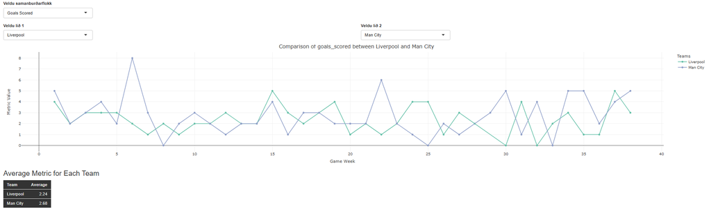

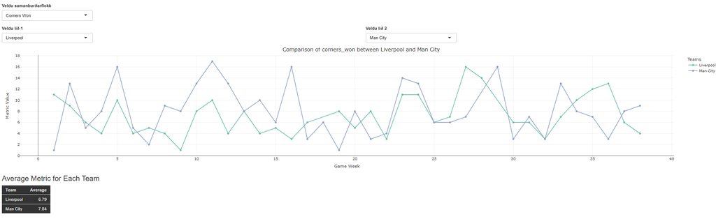

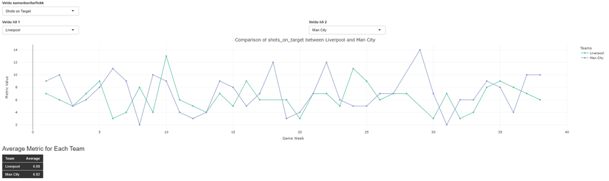

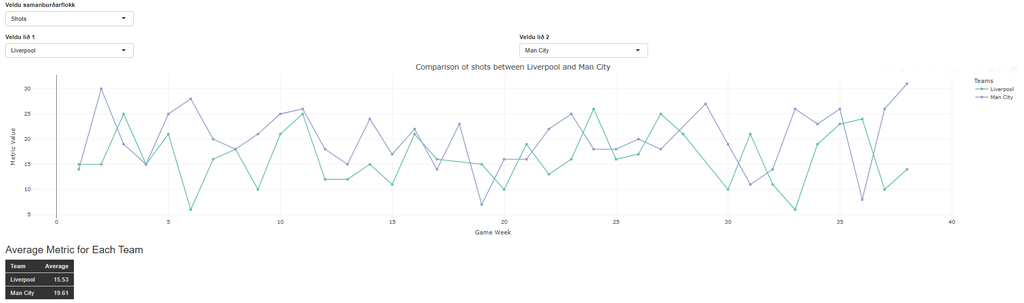

```r
include_graphics(c("C:/Users/jakob/Pictures/mælaborð/livcitymark.PNG",
                   "C:/Users/jakob/Pictures/mælaborð/livcityhorn.PNG",
                   "C:/Users/jakob/Pictures/mælaborð/livcityskotmark.PNG",
                   "C:/Users/jakob/Pictures/mælaborð/livcityskot.PNG"))
```

Þessar niðurstöður gefa sterklega til kynna að sóknarleikur þessara tveggja liða hafi átt stóran þátt í að tryggja þeim 1. og 2. sæti í deildinni á þessu tímabili.

Hins vegar er árangursríkur sóknarleikur einn og sér ekki nóg til að ná toppárangri; það er blanda af frábærum sóknarleik og traustum varnarleik sem gerir heildarframmistöðu liðanna svona áhrifamikla.

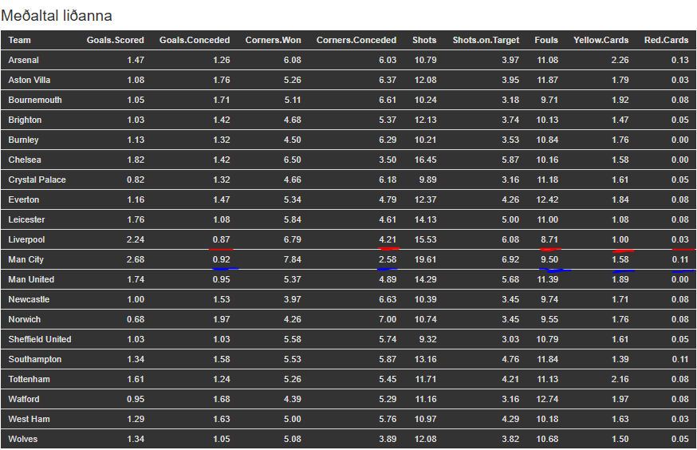

Samt sem áður gefur þessi niðurstaða til kynna að bæði lið leggi áherslu á agaðan varnarleik og takmarkaða brotnotkun til að viðhalda stöðugum varnarárangri.

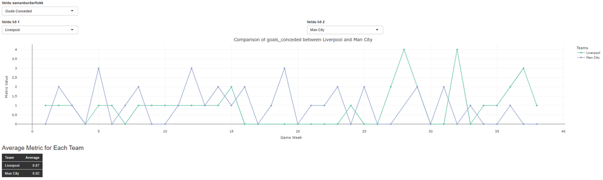

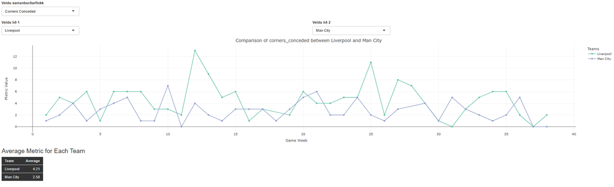

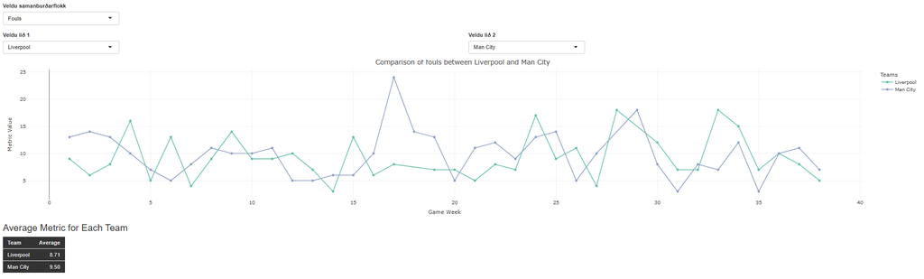

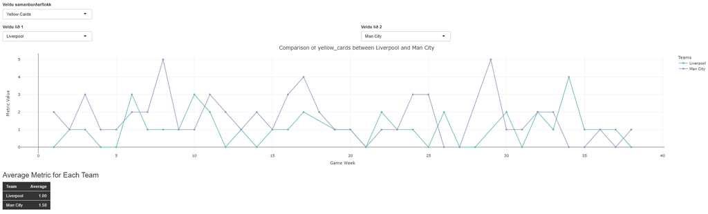

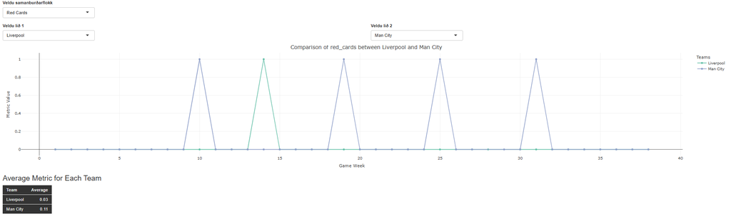

```r
include_graphics(c("C:/Users/jakob/Pictures/mælaborð/morkfengincityliv.PNG",
                   "C:/Users/jakob/Pictures/mælaborð/cornersfengin.PNG",
                   "C:/Users/jakob/Pictures/mælaborð/brot.PNG",
                   "C:/Users/jakob/Pictures/mælaborð/gult.PNG",
                   "C:/Users/jakob/Pictures/mælaborð/rautt.PNG"))
```

Heildarniðurstöður greiningarinnar á ensku úrvalsdeildinni 2019/20 gefa djúpa innsýn í árangur og frammistöðu liðanna, sem skýrast með samanburði á heimavallarárangri, færninytingu leikmanna og veðmálatölfræði. Heimavöllurinn skiptir verulegu máli þegar kemur að úrslitum leikja, þar sem öll lið í deildinni ná betri árangri á heimavelli en á útivelli. Þetta er líklega vegna stuðnings áhorfenda, ásamt því að leikmenn eru kunnugir leikskilyrðum á heimavelli. Þessi þáttur eykur líkurnar á góðum árangri og sýnir hvernig ytri umgjörð leikja getur haft bein áhrif á frammistöðu liða.

Færninyting leikmanna var einnig skoðuð sérstaklega með það fyrir augum að bera saman hverjir nýta færi sín best. Þar kemur Danny Ings úr Southampton sterkastur inn og skoraði mark á hverjum 127 mínútum með aðeins 1.72 skot á mark að meðaltali til að skora. Þetta gefur til kynna að Ings var ekki aðeins markahæfur, heldur náði hann einnig að nýta færin sín betur en aðrir markaskorarar eins og Jamie Vardy og Mohamed Salah, sem þurftu fleiri skot til að skora mark. Þessar upplýsingar geta verið mikilvægar fyrir þá sem vilja dýpra innsýn í leikmannagildi og árangur á vellinum.

Við skoðun á sóknar- og varnarframmistöðu liða kemur fram að Liverpool og Manchester City eru með afgerandi yfirburði í flestum sóknarflokkum, svo sem mörkum skoruðum, hornum og skotum á mark. Þessi sóknarstyrkur skilar sér í góðri stöðu í deildinni, þar sem þessi lið náðu fyrsta og öðru sæti. En það er ekki bara sóknin sem tryggir þeim árangur; Liverpool fékk á sig fæst mörk allra liða, sem endurspeglar mikilvægi varnarleiksins. Þetta jafnvægi á milli sóknar og vörn hefur augljóslega mikið að segja þegar kemur að því að ná langt í deildinni.

Veðmálatölfræðin sýnir svo að liðið Wolves, þrátt fyrir að vera ekki í efstu sætum, skilaði mestum hagnaði fyrir veðmálara vegna þess að stuðlarnir á þá voru hærri. Ólíklegri sigurliðum, eins og Wolves, er oft gefinn hærri stuðull af veðmálasíðum, sem þýðir að sigur í leikjum þeirra skilar meira en sigur hjá sigurstranglegri liðum eins og Liverpool eða Manchester City. Liverpool, sem vann deildina, skilaði tiltölulega lágu veðmálahagnaði, þar sem stuðlarnir á þá voru lægri vegna mikilla sigurlíkinda. Þessi nálgun sýnir hvernig veðmál geta varpað ljósi á áhugaverða fjármálalega hlið á frammistöðu liða og mikilvægi stuðla þegar kemur að hagnaði.

## 3.4 Gæðamat Gagna

Í heildina eru gögnin umfangsmikil, fjölbreytt og veita sterka innsýn í frammistöðu liðanna í ensku úrvalsdeildinni. Þó er vert að hafa í huga að uppruni gagnanna frá mismunandi gagnaveitum – þar á meðal GitHub, Kaggle og FotMob – getur haft áhrif á samræmi og nákvæmni þeirra. Til að lágmarka skekkjumöguleika beittum við gagnahreinsun með SQL og Regex til að tryggja að gögnin væru flokkuð rétt og sett fram á stöðluðu formi.

Engu að síður geta flóknar breytingar, handvirk skráning og mismunandi skráningarstaðlar frá gagnaveitunum haft áhrif á gæði gagnanna og skapað möguleika á smávægilegum skekkjum í greiningunni.

Þrátt fyrir ítarlega gagnahreinsun og úrvinnslu má gera ráð fyrir að villur gætu verið til staðar í einhverjum CSV skránum. Slíkar villur gætu verið vegna smávægilegra skráningarmistaka, eins og rangar tölur í einstökum reitum. Þetta gæti leitt til skekkju í niðurstöðum án þess að það væri augljóst í greiningarferlinu og hefði þá áhrif á útkomu í gröfum án okkar vitundar. Til dæmis gæti rangur markafjöldi í einum leik snúið niðurstöðum í samanburðargrafi við önnur lið, eða rangir stuðlar, sem myndi gefa röng merki um raunverulega frammistöðu.

## 3.5 Ályktun

Greining okkar á ensku úrvalsdeildinni 2019/20 leiddi í ljós margþætta innsýn í hegðun liða, leikmanna og annarra lykilþátta, sem varpar ljósi á flókna samspilið á milli sóknar, varnar, aga og ytri áhrifa eins og heimavallar og stuðnings. Með því að nýta fjölbreytt gagnasafn frá mismunandi uppsprettum ásamt gagnvirku mælaborði tókst okkur að draga fram bæði þekkt og óvænt mynstur.

Árangur Liverpool og Manchester City sýnir fram á mikilvægi jafnvægis í sókn og vörn. Liverpool nýtti styrkleika sína í agaðri vörn og færri brotum til að tryggja sér titilinn, á meðan Manchester City hélt uppi sterkri sókn og sköpun á vellinum. Á hinn bóginn var sérstakt að sjá Wolves, sem skaraði fram úr í veðmálagreiningunni og sýndi að ólíklegri sigurlið geta haft áhrif á fjárhagslega hlið íþrótta. Þetta undirstrikar fjölbreyttan eðli frammistöðugreiningar og nauðsyn þess að líta á fleiri þætti en bara stig í töflu.

Danny Ings stóð sig best í marknýtingu, en niðurstöðurnar undirstrika einnig að einstaklingsárangur er aðeins hluti af stærri myndinni. Liverpool varð sigurvegari, þrátt fyrir að leikmenn þess væru ekki með bestu marknýtinguna, sem sýnir að heildarárangur liðs vegur þyngra en einstakar tölur leikmanna.

Heimavöllurinn spilaði afgerandi hlutverk, þar sem hann veitti liðunum mikilvægt forskot, bæði í efstu og neðstu sætum deildarinnar. Þetta styrkir skilning okkar á áhrifum ytri þátta á árangur. Að sama skapi undirstrika gögnin mikilvægi vandaðrar gagnaöflunar, hreinsunar og úrvinnslu til að tryggja áreiðanlegar niðurstöður.

Að lokum hefur verkefnið sýnt fram á hvernig gagnagreining og sjónræn framsetning getur auðgað skilning á flóknum kerfum eins og ensku úrvalsdeildinni. Þetta mælaborð er dýrmætt verkfæri fyrir knattspyrnuáhugamenn, tölfræðinga og aðila í íþróttaiðnaði, þar sem það sameinar ítarlega greiningu og notendavænt viðmót sem leiðir til aukinnar upplýsingaöflunar og innsæis í fótboltaheiminum.